# Some hypothesis tests with `R`

Víctor Peña

# One normal mean

A group of scientists recorded some measurements that are stored in the vector `x`:

```r
x = c(1,4,2,3,6,9,1,3,9,3)
```

We can find the mean and standard deviation of `x` as follows:

```r
mean(x)
```

```
## [1] 4.1
```

```r
sd(x)
```

```
## [1] 2.960856
```

The function `summary` provides quantiles, minimum, maximum, etc.

```r
summary(x)
```

```
##    Min. 1st Qu.  Median    Mean 3rd Qu.    Max.
##    1.00    2.25    3.00    4.10    5.50    9.00
```

We can visualize `x` with a histogram or a boxplot, for example.

The plots below are created using the functions `hist` and `boxplot`, which are in `library(graphics)`:

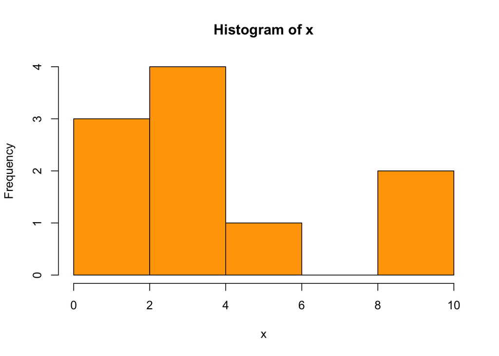

```r
hist(x, col = 'orange')
```

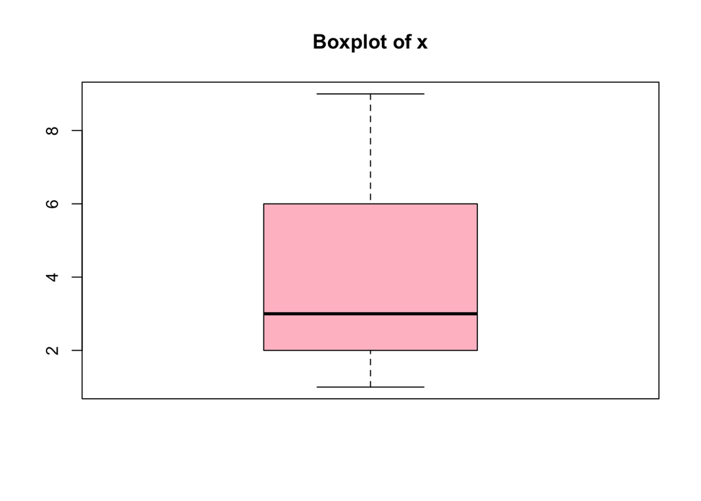

```r
boxplot(x, col = 'pink', main = "Boxplot of x")
```

We can do $t$-tests and find normal confidence intervals for the population mean $\mu$ with the function `t.test`.

For example, if we want to find a 99% confidence interval for the mean:

```r
t.test(x, conf.level = 0.99)
```

```
##
##  One Sample t-test
##
## data:  x
## t = 4.3789, df = 9, p-value = 0.001774
## alternative hypothesis: true mean is not equal to 0
## 99 percent confidence interval:
##  1.057163 7.142837
## sample estimates:
## mean of x
##       4.1
```

We can change `conf.level` to any confidence level that we want. If we don’t specify anything, the default is 95% confidence.

As you can see, `t.test` gives us a $p$-value. The output is self-explanatory: the $p$-value corresponds to the test $H_0: \mu = 0$ against $H_1: \mu \neq 0$. If we want to change the hypothesized value under the null to some value that is not 0, we can change the argument `mu` of `t.test`. If we want to change the alternative to “less than” or “greater than”, instead of “not equal to”, we can set `alternative` to `less` or `greater`, respectively.

For instance, if we want to test $H_0: \mu = 5$ against $H_1 : \mu < 5$, the following `R` code will do it for us:

```r
t.test(x, mu = 5, alternative = 'less')
```

```
##
##  One Sample t-test
##
## data:  x
## t = -0.96123, df = 9, p-value = 0.1808
## alternative hypothesis: true mean is less than 5
## 95 percent confidence interval:
##      -Inf 5.816352
## sample estimates:
## mean of x
##       4.1
```

As always, you can get more information about the function if you type in `?t.test`.

# Two independent normal means

A pharmaceutical is interested in knowing whether their new treatment is significantly different than the current gold standard. They collected a sample of 40 individuals: 20 of them were assigned the new treatment, and 20 of them were assigned the current treatment. The outcome is on an ordinal scale that goes from 0 to 100, where 0 is “bad” and 100 is “great”. The data can be found in the file `pharma.csv`, which is on the course website.

The data has 2 columns: `group` and `outcome`:

```r
summary(pharma)
```

```
##      group       outcome
##  current:20   Min.   : 80.00
##  new    :20   1st Qu.: 89.00
##               Median : 92.50
##               Mean   : 92.30
##               3rd Qu.: 98.25
##               Max.   :100.00
```

If we want to get summaries by group (means, standard deviations, etc.), there are different ways to do it. Here’s one:

```r
summary(pharma[pharma$group=='current',])
```

```
##      group       outcome
##  current:20   Min.   : 83.00
##  new    : 0   1st Qu.: 92.75
##               Median : 97.50
##               Mean   : 95.55
##               3rd Qu.:100.00
##               Max.   :100.00
```

```r
summary(pharma[pharma$group=='new',])
```

```
##      group       outcome
##  current: 0   Min.   : 80.00
##  new    :20   1st Qu.: 85.25
##               Median : 89.50
##               Mean   : 89.05
##               3rd Qu.: 92.25
##               Max.   :100.00
```

We’ll see other ways of creating summaries by different `levels` of a `factor` later in the semester.

If we want to plot the outcomes by group, we can create a boxplot:

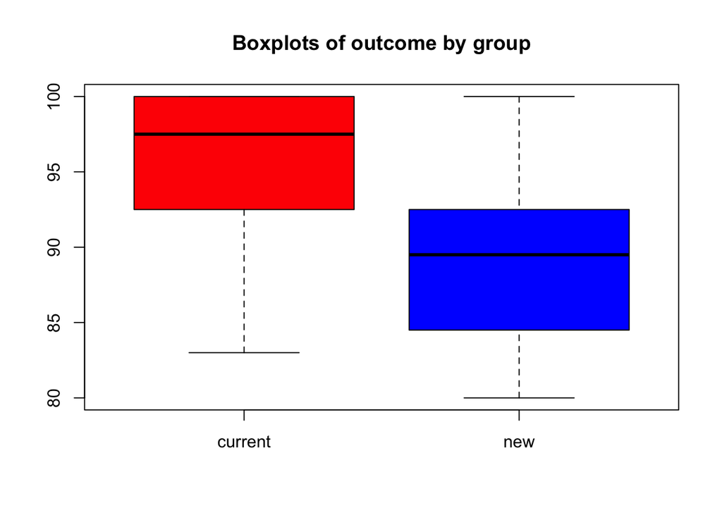

```r
boxplot(outcome ~ group,
        data = pharma,
        main = "Boxplots of outcome by group",
        col = c('red', 'blue'))
```

We could’ve also used the command `boxplot(pharma$outcome ~ pharma$group)`, but I think the command above is cleaner.

If we want to create histograms of outcomes by groups, here’s an option:

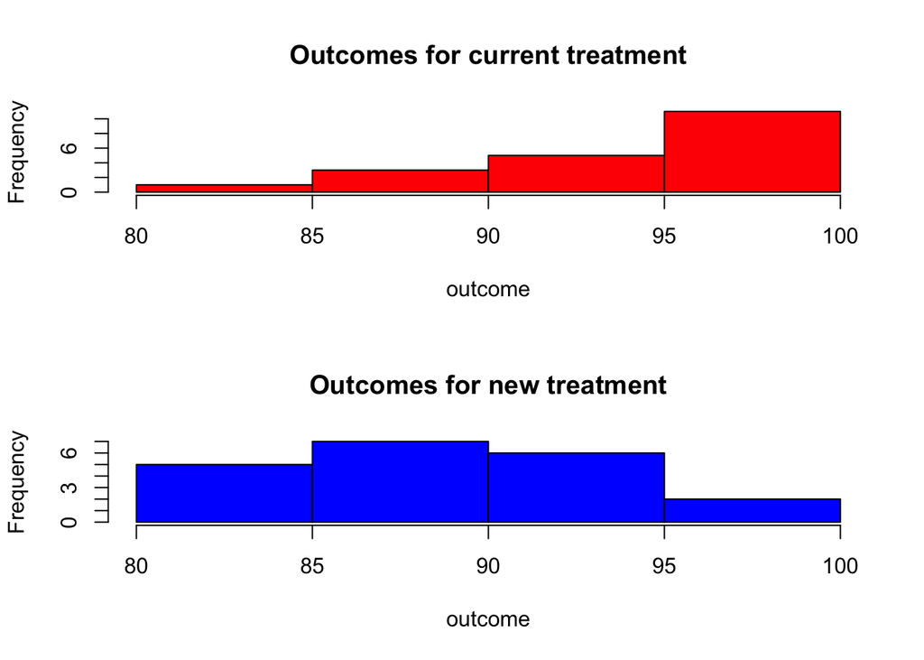

```r
par(mfrow=c(2,1))
hist(pharma$outcome[pharma$group=='current'],
     main = "Outcomes for current treatment",
     xlab='outcome',
     col = 'red')

hist(pharma$outcome[pharma$group=='new'],
     main = "Outcomes for new treatment",
     xlab = 'outcome',
     col = 'blue')
```

Some comments on the code:

- `par(mfrow=c(2,1))` tells `R` that we want a plot that has 2 rows and 1 column
- `xlab` changes the label on the `x`-axis of the plot

The pharmaceutical is interested in knowing whether the population means of the health outcomes are different at the 0.01 significance level. That is, if $\mu_C$ and $\mu_N$ are the population means of `outcome` for the current and new treatments, respectively, the pharmaceutical wants to test $H_0: \mu_C = \mu_N$ against $H_1 : \mu_C \neq \mu_N$ at the 0.01 significance level.

We can do a two-sample $t$-test with `t.test`:

```r
t.test(outcome ~ group, conf.level = 0.99, data = pharma)
```

```
##
##  Welch Two Sample t-test
##
## data:  outcome by group
## t = 3.8381, df = 37.451, p-value = 0.0004622
## alternative hypothesis: true difference in means is not equal to 0
## 99 percent confidence interval:
##   1.904267 11.095733
## sample estimates:
## mean in group current     mean in group new
##                 95.55                 89.05
```

We can change the hypothesized difference in means under the null with the argument `mu` and we can change the alternative to “less than” or “greater than” with the argument `alternative`, just as we did with the one-sample $t$-test we covered in the previous section.

As you can see, the treatments are significantly different at the 0.01 significance level (the $p$-value is less than 0.01 and the 99% confidence interval doesn’t cover 0). However, we wouldn’t recommend marketing this new drug: the new treatment is significantly *worse* than the current treatment.

# $\chi^2$-tests of independence for categorical variables

The `hsb2` dataset in `library(openintro)` has standardized test scores and background information for a sample of 200 highschoolers. Let’s read in the data:

```r
library(openintro)
data(hsb2)
```

If you want more information about the dataset, you can find it by typing `?hsb2`.

If we want to get a quick look at the variables in the dataset, we can use `str`:

```r
str(hsb2)
```

```
## 'data.frame':    200 obs. of  11 variables:
##  $ id     : int  70 121 86 141 172 113 50 11 84 48 ...
##  $ gender : chr  "male" "female" "male" "male" ...
##  $ race   : chr  "white" "white" "white" "white" ...
##  $ ses    : Factor w/ 3 levels "low","middle",..: 1 2 3 3 2 2 2 2 2 2 ...
##  $ schtyp : Factor w/ 2 levels "public","private": 1 1 1 1 1 1 1 1 1 1 ...
##  $ prog   : Factor w/ 3 levels "general","academic",..: 1 3 1 3 2 2 1 2 1 2 ...
##  $ read   : int  57 68 44 63 47 44 50 34 63 57 ...
##  $ write  : int  52 59 33 44 52 52 59 46 57 55 ...
##  $ math   : int  41 53 54 47 57 51 42 45 54 52 ...
##  $ science: int  47 63 58 53 53 63 53 39 58 50 ...
##  $ socst  : int  57 61 31 56 61 61 61 36 51 51 ...
```

Suppose that a team of social scientists want to test whether the distribution of `ses` depends on `race`. First, we can create a table:

```r
table(hsb2$ses, hsb2$race)
```

```
##
##          african american asian hispanic white
##   low                  11     3        9    24
##   middle                6     5       11    73
##   high                  3     3        4    48
```

It’s hard to see whether `race` depends on `ses` by looking at the raw counts. We can create columns with row and column percentages with `prop.table`. First, we save the original table with raw counts in a variable.

```r
tab = table(hsb2$ses, hsb2$race)
```

If we want row percentages (i.e. the sum of each row of the table is equal to 1):

```r
prop.table(tab, margin = 1)
```

```
##
##          african american      asian   hispanic      white
##   low          0.23404255 0.06382979 0.19148936 0.51063830
##   middle       0.06315789 0.05263158 0.11578947 0.76842105
##   high         0.05172414 0.05172414 0.06896552 0.82758621
```

If we want column percentages (i.e. the sum of each column of the table is equal to 1):

```r
prop.table(tab, margin = 2)
```

```
##
##          african american     asian  hispanic     white
##   low           0.5500000 0.2727273 0.3750000 0.1655172
##   middle        0.3000000 0.4545455 0.4583333 0.5034483
##   high          0.1500000 0.2727273 0.1666667 0.3310345
```

Finally, if we want overall percentages instead (i.e. the sum of all the entries in the table is equal to 1):

```r
prop.table(tab)
```

```
##
##          african american asian hispanic white
##   low               0.055 0.015    0.045 0.120
##   middle            0.030 0.025    0.055 0.365
##   high              0.015 0.015    0.020 0.240
```

These `prop.table`s aren’t very easy to look at, either: they have too many decimal places. We can round them as with `round`:

```r
round(prop.table(tab, margin = 1), 3)
```

```
##
##          african american asian hispanic white
##   low               0.234 0.064    0.191 0.511
##   middle            0.063 0.053    0.116 0.768
##   high              0.052 0.052    0.069 0.828
```

If we want 5 decimal places instead, we would change the 3 to a 5.

We can create barplots with the `tables` and `prop.tables`:

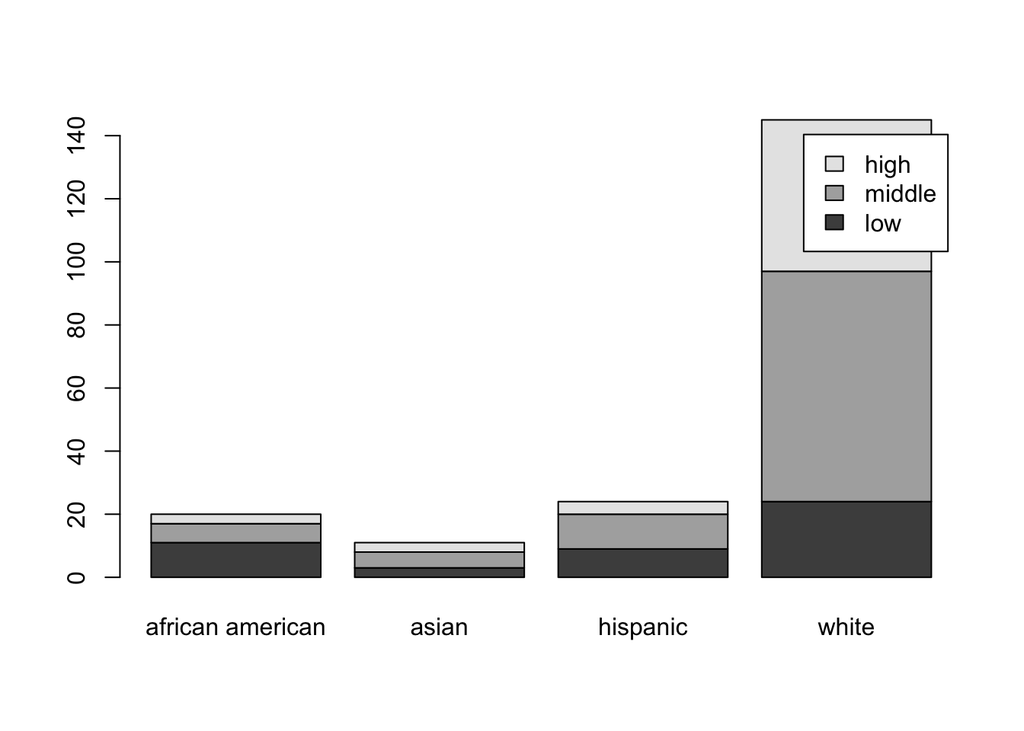

```r
barplot(tab, legend.text = T)
```

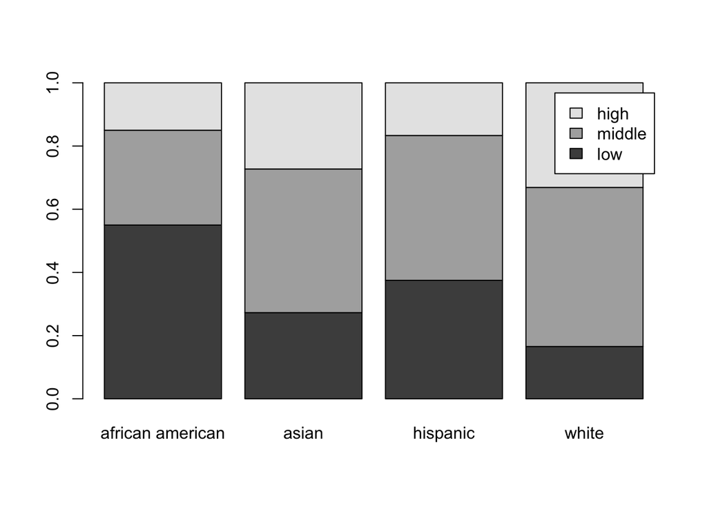

```r
barplot(prop.table(tab, margin = 2), legend.text = T)
```

The position of the legends isn’t good. We’ll see how to fix that later in the semester.

Finally, the code below runs a $\chi^2$-test:

```r
chisq.test(tab)
```

```
##
##  Pearson's Chi-squared test
##
## data:  tab
## X-squared = 18.516, df = 6, p-value = 0.005064
```

The $p$-value is significant at the 0.05 significance level.

# Pairwise comparisons of normal means: Tukey HSD

Suppose that we want to compare the average scores in `math` among the levels of `race` doing pairwise tests, using Tukey HSD. The code is simple:

```r
mod = aov(math~race, data=hsb2)
TukeyHSD(mod)
```

```
##   Tukey multiple comparisons of means
##     95% family-wise confidence level
##
## Fit: aov(formula = math ~ race, data = hsb2)
##
## $race
##                                 diff        lwr       upr     p adj
## asian-african american    10.5227273   1.838424 19.207030 0.0104479
## hispanic-african american  0.6666667  -6.337737  7.671071 0.9947149
## white-african american     7.2224138   1.704074 12.740754 0.0046342
## hispanic-asian            -9.8560606 -18.279657 -1.432465 0.0145446
## white-asian               -3.3003135 -10.535462  3.934835 0.6389480
## white-hispanic             6.5557471   1.457520 11.653975 0.0056430
```

You can check whether the pairwise differences are significant by checking the $p$-values. You can change the confidence level of the corrected intervals with the argument `conf.level`. For example, if we want 99% confidence intervals instead:

```r
TukeyHSD(mod, conf.level = 0.99)
```

```
##   Tukey multiple comparisons of means
##     99% family-wise confidence level
##
## Fit: aov(formula = math ~ race, data = hsb2)
##
## $race
##                                 diff          lwr        upr     p adj
## asian-african american    10.5227273  -0.04702112 21.0924757 0.0104479
## hispanic-african american  0.6666667  -7.85846043  9.1917938 0.9947149
## white-african american     7.2224138   0.50598962 13.9388380 0.0046342
## hispanic-asian            -9.8560606 -20.10849978  0.3963786 0.0145446
## white-asian               -3.3003135 -12.10628138  5.5056544 0.6389480
## white-hispanic             6.5557471   0.35064587 12.7608484 0.0056430
```

[output not shown]